# topic modeling, document clustering, and dimensionality reduction

# using TED Talks (2013)

### alexander johnson

### http://metasyn.pw

### general assembly, data science sf 11

```python
from __future__ import division # python 2, so old school
import numpy as np
import pandas as pd
import seaborn as sns
import nltk
import matplotlib.pyplot as plt
import re
from bs4 import BeautifulSoup
import codecs

from sklearn.feature_extraction.text import TfidfVectorizer
from sklearn.preprocessing import Normalizer
from sklearn.cluster import KMeans
from scipy.spatial.distance import cdist, pdist

from sklearn.cluster import KMeans
from mpl_toolkits.mplot3d import Axes3D
from sklearn.decomposition import TruncatedSVD
from sklearn.manifold import TSNE
from sklearn.decomposition import FastICA as ICA
from sklearn.decomposition import PCA

pd.set_option('display.max_rows', 10)

%matplotlib inline
```

```python
url_split[0].split('\n')[:10]
```

```
[u'stephen_palumbi_following_the_mercury_trail.html',
 u"There's a tight and surprising link between the ocean'shealth and ours, says marine biologist Stephen Palumbi. He showshow toxins at the bottom of the ocean food chain find their wayinto our bodies, with a shocking story of toxic contamination froma Japanese fish market. His work points a way for…
 u'fish,health,mission blue,oceans,science',
 u'899',
 u'Stephen Palumbi: Following the mercury trail',
 u'',
 u'It can be a very complicated thing, the ocean.',
 u'And it can be a very complicated thing, what human healthis.',
 u'And bringing those two together might seem a very dauntingtask,',
 u"but what I'm going to try to say is that even in thatcomplexity, there's some simple themes that I think, if weunderstand, we can really move forward."]
```

```python
def getRealWords(word, dictionary):
    if word in dictionary:
        return str(word)
    else:
        wordlength = len(word)
        for i in range(wordlength):
            part = word[:i]
            if part in dictionary:
                if word[i:] in dictionary:
                    return str(part) + ' ' + str(word[i:])

        return str(word)

def processText(text, dictionary):
    string = u''
    words = text.split()
    for word in words:
        if word in stopwords:
            pass
        else:
            string += ' ' + getRealWords(word, dictionary)
    return string
```

```python
df.head()
```

|  | author | topics | url | text |
| --- | --- | --- | --- | --- |
| 0 | Stephen Palumbi: Following the mercury trail | fish,health,mission blue,oceans,science | stephen_palumbi_following_the_mercury_trail.html | complicated thing ocean complicated thing huma... |
| 1 | Jessa Gamble: Our natural sleep cycle | evolution,humanity,personal growth,science,self | jessa_gamble_how_to_sleep.html | start day night life evolved condition light d... |
| 2 | Handspring Puppet Co.: The genius puppetry beh... | animals,arts,design,entertainment,theater | handpring_puppet_co_the_genius_puppetry_behind... | adrian kohler today talk evolution puppet hors... |
| 3 | Katherine Fulton: You are the future ofphilant... | activism,bottom-up,community,globalissues,phil... | katherine_fulton_you_are_the_future_of_philant... | philanthropy wha tit relationship offer vision... |
| 4 | Chris Gerdes: The future race car -- 150mph, a... | cars,future,technology | chris_gerdes_the_future_race_car_150mph_and_no... | wheel car driving road long day wanted tired f... |

```python
topic_words = []
for topics in df.topics:
    for topic in topics.split(','):
        topic_words.append(topic)
clean_topics = processText(' '.join(topic_words), dictionary).split()
tpx = pd.DataFrame(clean_topics, columns=['topics'])
tpx.topics.value_counts()[:10]
```

```
technology       410
science          321
culture          317
design           285
global           278
issues           278
entertainment    207
business         199
arts             138
health           110
dtype: int64
```

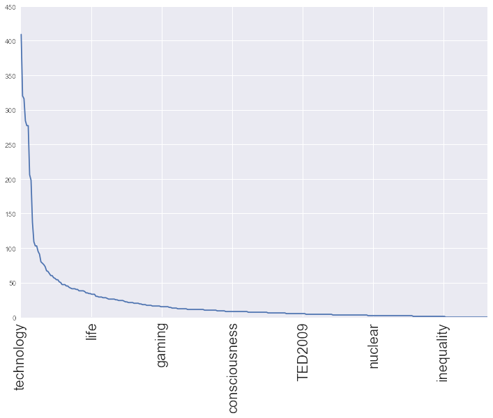

```python
tpx.topics.value_counts().plot(rot=90, figsize=(12,8), fontsize=20)
```

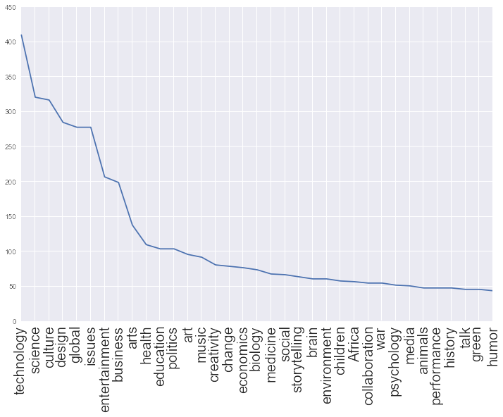

```python
tpx.topics.value_counts()[:35].plot(rot=90, xticks=range(35), figsize=(12,8), fontsize=20)
```

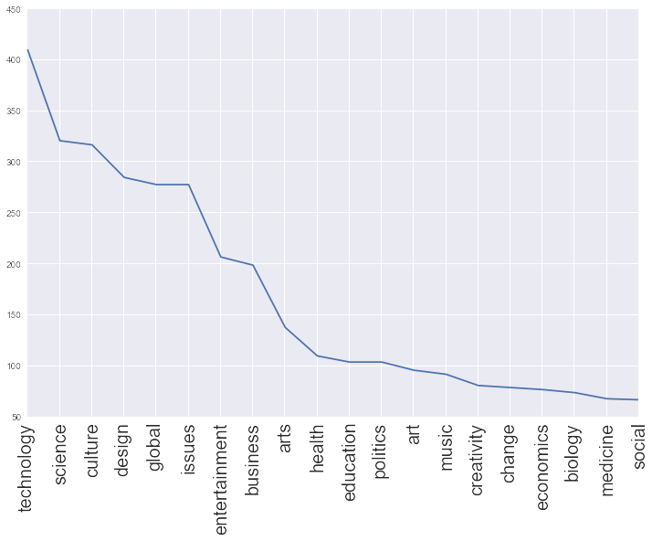

```python
tpx.topics.value_counts()[:20].plot(rot=90, xticks=range(20), figsize=(12,8), fontsize=20)
```

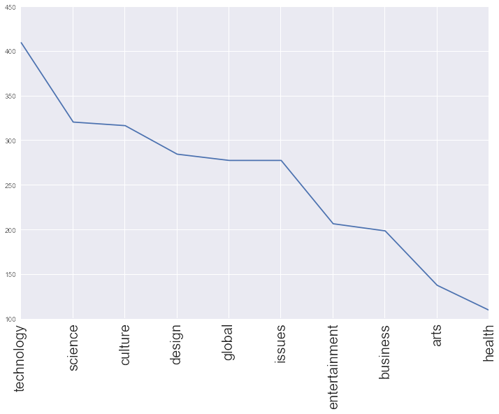

```python
tpx.topics.value_counts()[:10].plot(rot=90, xticks=range(10), figsize=(12,8), fontsize=20)
```

```python
# Estimating K

k_range = range(5, 100, 5)
k_variance = [KMeans(n_clusters=k).fit(similarity_matrix) for k in k_range]
k_centroids = [X.cluster_centers_ for X in k_variance]
```

```python
k_cosine = [cdist(similarity_matrix, cent, 'cosine') for cent in k_centroids]
distances = [np.min(ke, axis=1) for ke in k_cosine]

# Within-cluster sum of squares
wcss = [sum(d**2) for d in distances]
# Total sum of squares
tss = sum(pdist(similarity_matrix**2/similarity_matrix.shape[0]))
# Between cluster sum of squares
bss = tss - wcss
```

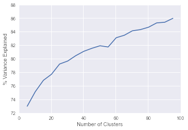

```python
plt.plot(k_range, bss/tss*100)
plt.xlabel("Number of Clusters")
plt.ylabel("% Variance Explained")
```

# Estimating K

So when k is 10, we get around 75% ! Whereas we get another 10% by increasing to nearly 100. If we look at the topic distributions we plotted earlier, we'll see that there isn't much reason to focus much more than 10~20 topics.

# So... now what...?

Now that we've clustered the documents in this huge vector space, we could peruse through them and see if the cluster members correlate to concepts we think are useful or interesting. I'm going to do this with k=10.

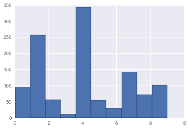

```python
tendf.cluster_id.hist()
```

# Looking Deeper: Top Terms per Cluster

So this is really just one way of looking at our clusters. Our clusters are made of text, so lets look at the most frequently occuring terms, per cluster.

### Topic 1: Everything

```
technology       160
design           145
culture          116
science           96
business          73
entertainment     66
arts              52
art               49
creativity        42
education         40
```

We'll that seems pretty general. Can't take too much from that - except that it talks alot about technology and design and culture... This is the most general category; it covers the T. E. and D. of TED. Since we can see that technology is number one, with a close second of design, then we move to seeing some of our other topics show up.

### Topic 2: Everything Pt.2

```
culture          119
entertainment     78
issues            71
global            71
arts              49
storytelling      46
technology        45
design            40
education         38
business          35
```

Much more focused here on culture, entertainment, and global issues.

### Topic 3: Green Tech?

```
technology     81
science        53
design         51
business       42
global         42
issues         42
environment    36
green          35
energy         30
invention      25
```

Hmm, once again, technology, design, business, but focusing more towards green energy at the end there.

### Topic 4 : Politics / Global Issues

```
issues        106
global        106
politics       49
culture        44
business       34
economics      31
health         29
Africa         28
technology     28
war            22
```

Here we actually see a departure from the earlier topics; were talking more about global issues, business, war, politics.

### Topic 5 : Art?

```
music            38
entertainment    37
performance      19
talk             16
arts             16
short            16
technology       16
design           13
live             12
culture          11
```

This is obviously more about art ! Music, performance, live performances.

### Topic 6 : Health

```
science       53
technology    37
medicine      25
health        22
brain         19
biology       15
cancer        10
care          10
research       9
medical        9
```

### Topic 7: Oceans

```
science        33
oceans         28
technology     15
issues         12
mission        12
global         12
fish           12
blue           12
environment    10
exploration    10
```

### Topic 8: Space

```
science        27
physics        17
universe       17
technology     16
astronomy      12
cosmos          6
space           6
exploration     6
education       4
change          4
```

### Topic 9: Robots

```
robots           12
technology       12
design            8
science           5
entertainment     3
engineering       3
evolution         3
animals           2
demo              2
AI                2
```

### Topic 10: ?

```
animals         3
issues          2
oceans          2
global          2
science         2
biodiversity    1
storytelling    1
culture         1
photography     1
creativity      1
```

```python
for i in cluster_topics:
    print i.topics.value_counts()[:10]
    print '$' * 70
```

```
design           154
technology       149
culture          107
entertainment     72
science           72
arts              67
business          60
art               59
education         50
creativity        46
dtype: int64
$$$$$$$$$$$$$$$$$$$$$$$$$$$$$$$$$$$$$$$$$$$$$$$$$$$$$$$$$$$$$$$$$$$$$$
global        143
issues        143
culture        93
business       78
politics       67
technology     58
economics      52
health         49
science        39
Africa         39
dtype: int64
$$$$$$$$$$$$$$$$$$$$$$$$$$$$$$$$$$$$$$$$$$$$$$$$$$$$$$$$$$$$$$$$$$$$$$
music            70
entertainment    69
culture          33
technology       33
design           30
arts             29
performance      27
talk             22
short            22
live             18
dtype: int64
$$$$$$$$$$$$$$$$$$$$$$$$$$$$$$$$$$$$$$$$$$$$$$$$$$$$$$$$$$$$$$$$$$$$$$
culture          53
issues           39
global           39
women            30
```

[output cut: 65 more lines]

```
education       4
dtype: int64
$$$$$$$$$$$$$$$$$$$$$$$$$$$$$$$$$$$$$$$$$$$$$$$$$$$$$$$$$$$$$$$$$$$$$$
robots           12
technology       12
design            8
science           5
entertainment     3
engineering       3
evolution         3
animals           2
demo              2
AI                2
dtype: int64
$$$$$$$$$$$$$$$$$$$$$$$$$$$$$$$$$$$$$$$$$$$$$$$$$$$$$$$$$$$$$$$$$$$$$$
```

```python
for i in cluster_text:
    print i.text.value_counts()[:10]
    print '-'*70
```

```
thing     3388
people    2888
time      2106
kind      1684
year      1571
world     1538
work      1523
lot       1136
life      1091
idea      1047
dtype: int64
----------------------------------------------------------------------
people     3856
world      2048
thing      1683
year       1594
time       1378
country    1027
life        879
lot         798
good        795
problem     772
dtype: int64
----------------------------------------------------------------------
thing     390
people    366
time      311
music     310
world     264
year      240
good      233
life      218
sound     206
kind      189
dtype: int64
----------------------------------------------------------------------
woman     927
people    632
year      492
time      472
```

[output cut: 65 more lines]

```
life        140
dtype: int64
----------------------------------------------------------------------
robot     344
thing      60
foot       59
animal     58
time       54
leg        49
doe        45
people     42
work       41
kind       37
dtype: int64
----------------------------------------------------------------------
```

```python
import gensim
```

```python
all_text = [doc.split() for doc in df.text]
```

```python
gensim_d = gensim.corpora.Dictionary(all_text)
```

```python
corpus = [gensim_d.doc2bow(text) for text in all_text]
```

```python
lda = gensim.models.ldamodel.LdaModel(corpus=corpus, id2word=gensim_d, num_topics=10, update_every=1, chunksize=100, passes=1)
```

```python
lda_topics = lda.print_topics(10)
lda_tops = [topic.split('+') for topic in lda_topics]
for topic in lda_tops:
    for pair in topic:
        print pair.split('*')[0] + '\t' + pair.split('*')[1]
    print '%' * 70
```

```
0.015	cell
 0.011	patient
 0.011	food
 0.008	disease
 0.008	cancer
 0.007	body
 0.007	brain
 0.006	heart
 0.006	people
 0.006	year
%%%%%%%%%%%%%%%%%%%%%%%%%%%%%%%%%%%%%%%%%%%%%%%%%%%%%%%%%%%%%%%%%%%%%%
0.014	space
 0.009	universe
 0.008	particle
 0.007	thing
 0.007	earth
 0.007	light
 0.006	planet
 0.006	tree
 0.006	theory
 0.006	time
%%%%%%%%%%%%%%%%%%%%%%%%%%%%%%%%%%%%%%%%%%%%%%%%%%%%%%%%%%%%%%%%%%%%%%
0.017	brain
 0.014	human
 0.009	thing
 0.008	people
 0.006	life
 0.006	time
 0.006	year
 0.006	gene
 0.004	evolution
 0.004	genome
%%%%%%%%%%%%%%%%%%%%%%%%%%%%%%%%%%%%%%%%%%%%%%%%%%%%%%%%%%%%%%%%%%%%%%
0.014	people
 0.013	world
 0.013	country
 0.009	africa
 0.009	year
 0.007	woman
 0.006	government
```

[output cut: 55 more lines]

```
 0.005	kid
 0.005	story
 0.005	school
%%%%%%%%%%%%%%%%%%%%%%%%%%%%%%%%%%%%%%%%%%%%%%%%%%%%%%%%%%%%%%%%%%%%%%
0.009	people
 0.007	language
 0.007	baby
 0.007	child
 0.006	love
 0.006	time
 0.005	year
 0.005	thing
 0.004	learning
 0.004	english
%%%%%%%%%%%%%%%%%%%%%%%%%%%%%%%%%%%%%%%%%%%%%%%%%%%%%%%%%%%%%%%%%%%%%%
```

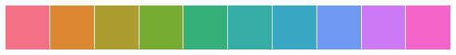

```python
# Nice husl from seaborn
colors = sns.husl_palette(n_colors=10)
sns.palplot(colors)
```

[figure not shown]

```python
colors.reverse()
sns.palplot(colors)
```

# Dimensionality Reduction

Google:

> In machine learning and statistics, dimensionality reduction or dimension reduction is the process of reducing the number of random variables under consideration, and can be divided into feature selection and feature extraction.

### Visualizing data is important

However, it's quite hard to visualize 1000's of dimensions. So below, I go about plotting our clusters in **3** dimensions; yes - we are losing tons of data ! But, this reduction allows us to actually **see** the data. In order to do these reductions, I compare the following dimensionality reduction algorithms.

### [Principal Component Analysis](http://en.wikipedia.org/wiki/Principal_component_analysis)

Simply put, PCA is a way of finding the most important parts some data set. More exactly, it's an orthogonal transformation of observations into some number of linearally uncorrelated variables, in this case, trying to summarize 1000's of dimensions into three. Basically, the first principle component is the component which accounts for this highest variance of the data (it explains the most), and the subsequent component(s) is the next in terms of variance explanation and also orthogonal (i.e. uncorrelated) with the previous component(s).

### [Singular Value Decomposition](http://en.wikipedia.org/wiki/Singular_value_decomposition)

Very similar to PCA. A gross simplification; SVD is a way of factorizing a large matrix into 3 sub parts. These 3 parts can re-create the matrix, so we take some of one of the components to make a smaller, approximated copy of the original.

### [t-Distributed Stochastic Neighbor Embedding](http://en.wikipedia.org/wiki/T-distributed_stochastic_neighbor_embedding)

This is a fascinating algorithm. It has a few main parts. Firstly, it creates a probability distribution that represents similarity between points (in the high dimensional space). Then, it creates a similar probability distribution over the low dimensional space and then minimizes the distance between the two (Kullback-Leibler divergence).

### [Independent Component Analysis](http://en.wikipedia.org/wiki/Independent_component_analysis)

Wikipedia:

> ICA finds the independent components (also called factors, latent variables or sources) by maximizing the statistical independence of the estimated components.

Basically:

> Typical algorithms for ICA use centering (subtract the mean to create a zero mean signal), whitening (usually with the eigenvalue decomposition), and dimensionality reduction as preprocessing steps in order to simplify and reduce the complexity of the problem for the actual iterative algorithm. Whitening and dimension reduction can be achieved with principal component analysis or singular value decomposition.

```python
def plot_reduction_kmeans(first_reduction, first_num, second_reduction, second_num, matrix=similarity_matrix):

    # Reduction #1
    f = first_reduction(n_components=first_num)
    f_matrix = f.fit_transform(matrix)

    # Reduction #2 1000 dimensions ->3 dimensions
    s = second_reduction(n_components=second_num)
    s_matrix = s.fit_transform(f_matrix)

    kmeans = KMeans(init='k-means++', n_clusters=10, n_init=100)
    kmeans.fit(s_matrix)

    d = {i:colors[i] for i in range(10)}
    kcolors = [d[i] for i in kmeans.labels_]

    fig = plt.figure()
    ax = fig.add_subplot(111, projection='3d')
    ax.scatter(s_matrix[:,0],s_matrix[:,1],s_matrix[:,2], c=kcolors, alpha=.6)
```

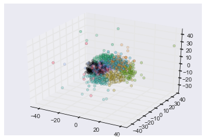

```python
plot_reduction_kmeans(TruncatedSVD, 100, TSNE, 3)
```

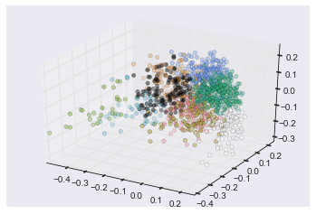

```python
plot_reduction_kmeans(TruncatedSVD, 100, PCA, 3)
```

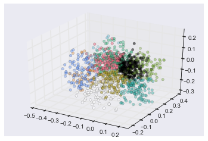

```python
plot_reduction_kmeans(TruncatedSVD, 500, PCA, 3)
```

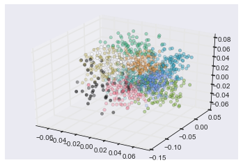

```python
plot_reduction_kmeans(TruncatedSVD, 100, ICA, 3)
```

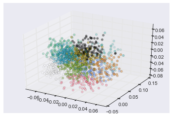

```python
plot_reduction_kmeans(TruncatedSVD, 500, ICA, 3)
```

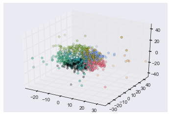

```python
plot_reduction_kmeans(PCA, 100, TSNE, 3)
```

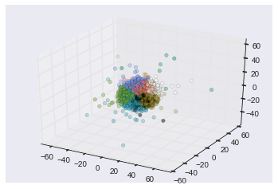

```python
plot_reduction_kmeans(PCA, 500, TSNE, 3)
```

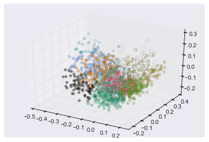

```python
plot_reduction_kmeans(PCA, 100, TruncatedSVD, 3)
```

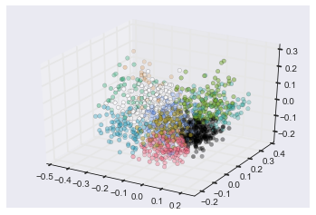

```python
plot_reduction_kmeans(PCA, 500, TruncatedSVD, 3)
```

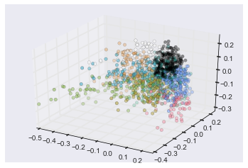

```python
plot_reduction_agg(PCA, 100, PCA, 3)
```

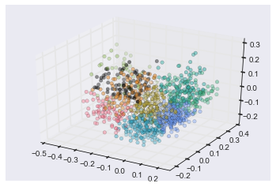

```python
## My favorite - for now

plot_reduction_kmeans(PCA, 500, TruncatedSVD, 3)
```

# More Visualizations

Interactive Visualization! https://github.com/datacratic/data-projector http://opensource.datacratic.com/data-projector/

```python
# Reduction #1
f = PCA(n_components=500)
f_matrix = f.fit_transform(similarity_matrix)

# Reduction #2 1000 dimensions ->3 dimensions
s = TruncatedSVD(n_components=3)
s_matrix = s.fit_transform(f_matrix)

kmeans = KMeans(init='k-means++', n_clusters=10, n_init=100)
kmeans.fit(s_matrix)

data_matrix = s_matrix.copy()
data_matrix = pd.DataFrame(data_matrix*200) # Gotta make everything a bit larger
data_matrix['cid'] = kmeans.labels_
data_matrix = data_matrix[[1,0,2,'cid']]
data_matrix.columns=['y','x','z','cid']
data_matrix.cid = data_matrix.cid.astype(int)
data_matrix = data_matrix.astype(str)
```

```python
data_matrix
```

|  | y | x | z | cid |
| --- | --- | --- | --- | --- |
| 0 | -13.0348188266 | -10.0552407715 | 34.6405097522 | 4 |
| 1 | -15.0734196879 | -16.0528409209 | 0.0902980978558 | 7 |
| 2 | 16.0918851228 | -29.1836998758 | -11.0857616069 | 3 |
| 3 | -0.935772800338 | 21.9657836093 | 5.74032885375 | 0 |
| 4 | -11.3979443438 | -18.4993158635 | -7.80118007466 | 7 |
| ... | ... | ... | ... | ... |
| 1164 | 3.52751145427 | -0.971211989561 | 22.1971858237 | 2 |
| 1165 | 33.7620250944 | 9.99174149862 | 13.9537345578 | 5 |
| 1166 | -11.1691445003 | 28.9441680889 | -11.2355379091 | 6 |
| 1167 | -22.3281534736 | -69.6905826011 | -0.572318236642 | 7 |
| 1168 | 14.2762038784 | 28.56306616 | 16.2803658902 | 8 |

1169 rows × 4 columns

http://metasyn.pw/ted-talk-topics/data-projector/index.html